# Mini Project 5

Richa Singh

11/13/2018

## Question 1

Consider the data stored in bodytemp-heartrate.csv on eLearning, containing measurements of body temperature and heart rate for 65 male (gender = 1) and 65 female (gender = 2) subjects.

1. Do males and females differ in mean body temperature? Answer this question by performing an appropriate analysis of the data, including an exploratory analysis.

```r
data <- read.csv("bodytemp-heartrate(2).csv")
data_male <- data[1:65,]
data_female <- data[66:130,]
```

```r
mean(data_male$body_temperature)
```

```
## [1] 98.10462
```

```r
mean(data_female$body_temperature)
```

```
## [1] 98.39385
```

[figure not shown]

```r
par(mfrow=c(2,1))
qqnorm(data_male$body_temperature, main="Q-Q plot for data of the body temperature of males in Farenheight")
qqline(data_female$body_temperature)
qqnorm(data_male$body_temperature, main="Q-Q plot for data of the body temperature of females in Farenheight")
qqline(data_female$body_temperature)
```

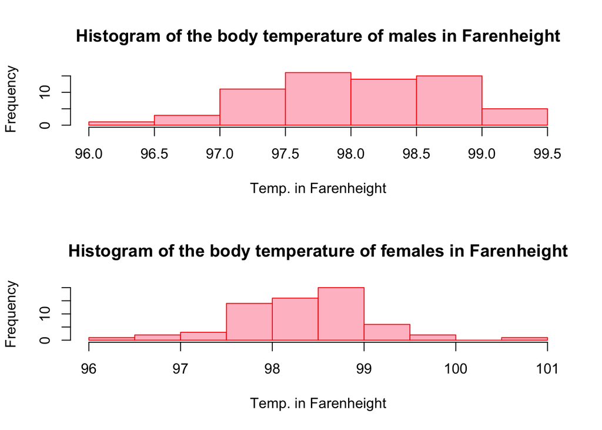

```r
par(mfrow=c(2,1))
hist(data_male$body_temperature,main = "Histogram of the body temperature of males in Farenheight",xlab = "Temp. in Farenheight",col = "pink",breaks = "Sturges",border = "red")
hist(data_female$body_temperature,main = "Histogram of the body temperature of females in Farenheight",xlab = "Temp. in Farenheight",col = "pink",breaks = "Sturges",border = "red")
```

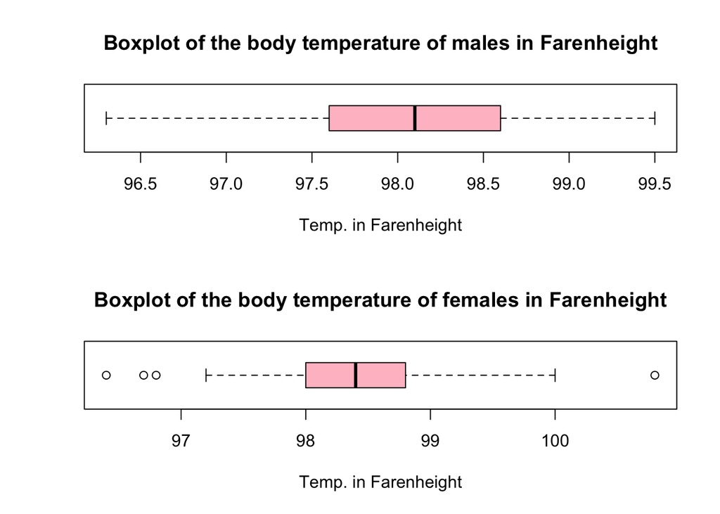

```r
par(mfrow=c(2,1))
boxplot(data_male$body_temperature,col = "pink",horizontal = TRUE,xlab="Temp. in Farenheight",main="Boxplot of the body temperature of males in Farenheight")
boxplot(data_female$body_temperature,col = "pink",horizontal = TRUE,xlab="Temp. in Farenheight",main="Boxplot of the body temperature of females in Farenheight")
```

The boxplot tells us that the variance for both the gender groups is different so now we know the following about the data:

- The data comes from an approximately normal distribution
- The variance for both the group is not same

Now performing the Hypothesis testing(Inferential Statistics) to validate the results:

Null Hypothesis: The difference in mean body temperature between the male and female group is zero.

Alternate Hypothesis : The difference in mean body temperature between male and female group is not zero.

```r
t.test(data_male$body_temperature, data_female$body_temperature, alternative = "two.sided", conf.level = 0.95,
    var.equal = FALSE)
```

```
##
##  Welch Two Sample t-test
##
## data:  data_male$body_temperature and data_female$body_temperature
## t = -2.2854, df = 127.51, p-value = 0.02394
## alternative hypothesis: true difference in means is not equal to 0
## 95 percent confidence interval:
##  -0.53964856 -0.03881298
## sample estimates:
## mean of x mean of y
##  98.10462  98.39385
```

From the above result we can say that the C.I comes out to be [-0.53964856 ,-0.03881298]. As, zero does not falls between [-0.53964856 ,-0.03881298] we here infer that the Null Hypothesis is rejected that is the mean body tempearture of male and the female group is not equal.

2. Do males and females differ in mean heart rate? Answer this question by performing an appropriate analysis of the data, including an exploratory analysis.

```r
mean(data_male$heart_rate)
```

```
## [1] 73.36923
```

```r
mean(data_female$heart_rate)
```

```
## [1] 74.15385
```

From the direct calculation of mean we can say that the mean heart rate of male and female group differs by 0.79

[figure not shown]

```r
par(mfrow=c(2,1))
qqnorm(data_male$heart_rate, main="Q-Q plot for data of the heart_rate of males in Farenheight")
qqline(data_female$heart_rate)
qqnorm(data_male$heart_rate, main="Q-Q plot for data of the heart_rate of females in Farenheight")
qqline(data_female$heart_rate)
```

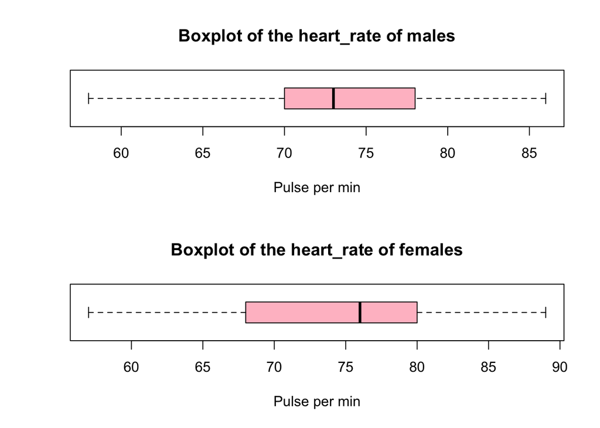

```r
par(mfrow=c(2,1))
boxplot(data_male$heart_rate,col = "pink",horizontal = TRUE,xlab="Pulse per min",main="Boxplot of the heart_rate of males")
boxplot(data_female$heart_rate,col = "pink",horizontal = TRUE,xlab="Pulse per min",main="Boxplot of the heart_rate of females")
```

The boxplot tells us that the variance for both the gender groups is different so now we know the following about the data:

- The data comes from an approximately normal distribution
- The variance for both the group is not same

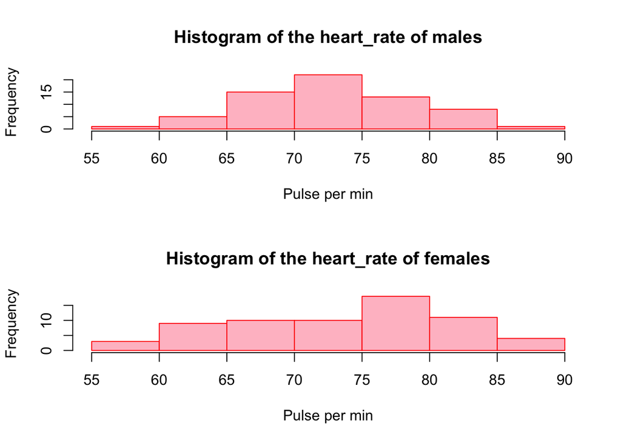

```r
par(mfrow=c(2,1))
hist(data_male$heart_rate,main = "Histogram of the heart_rate of males",xlab = "Pulse per min",col = "pink",breaks = "Sturges",border = "red")
hist(data_female$heart_rate,main = "Histogram of the heart_rate of females",xlab = "Pulse per min",col = "pink",breaks = "Sturges",border = "red")
```

Now performing the Hypothesis testing(Inferential Statistics) to validate the results:

Null Hypothesis: The difference in mean heart_rate between the male and female group is zero.

Alternate Hypothesis : The difference in mean heart_rate between male and female group is not zero.

```r
t.test(data_male$heart_rate, data_female$heart_rate, alternative = "two.sided", conf.level = 0.95,
    var.equal = FALSE)
```

```
##
##  Welch Two Sample t-test
##
## data:  data_male$heart_rate and data_female$heart_rate
## t = -0.63191, df = 116.7, p-value = 0.5287
## alternative hypothesis: true difference in means is not equal to 0
## 95 percent confidence interval:
##  -3.243732  1.674501
## sample estimates:
## mean of x mean of y
##  73.36923  74.15385
```

From the above result we can say that the C.I comes out to be [-3.243732, 1.674501]. As, zero does falls between [-3.243732, 1.674501] we here infer that the Null Hypothesis is accepted that is, the mean heart_rate of male and the female group is equal.

3. Is there a linear relationship between body temperature and heart rate? Does this relationship depend on gender? Answer these questions by performing an appropriate analysis of the data, including an exploratory analysis.

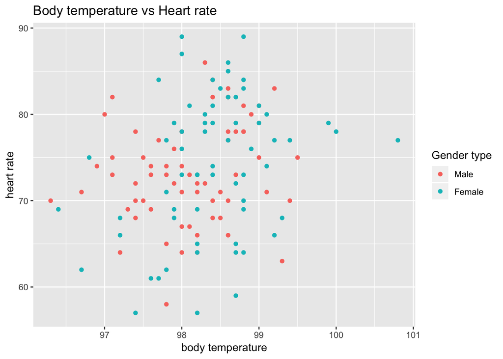

```r
library(ggplot2)
ggplot(data) + geom_point(aes(x=data$body_temperature, y=data$heart_rate, colour=factor(data$gender)))+ xlab("body temperature") + ylab("heart rate") + ggtitle("Body temperature vs Heart rate") + scale_color_discrete(name = "Gender type", labels = c( "Male" ,"Female" ))
```

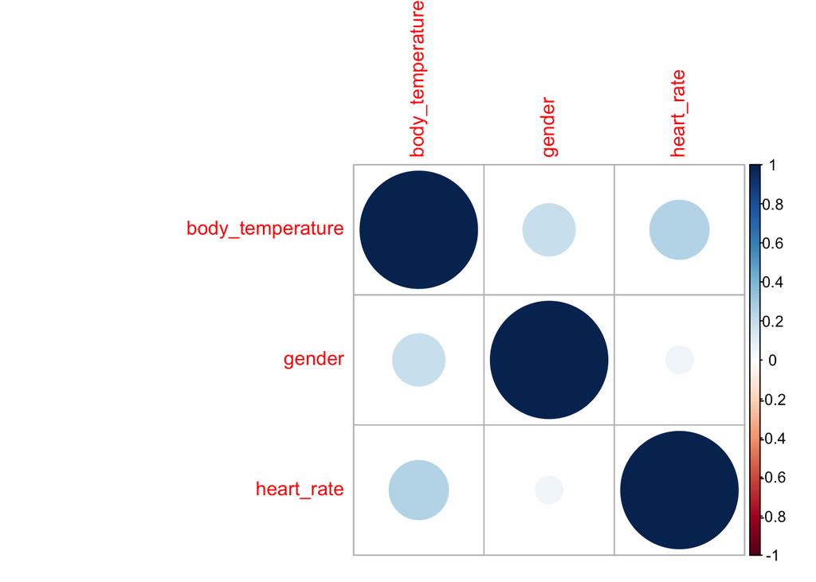

```r
corrplot::corrplot(cor(data))
```

```r
cor(data$body_temperature,data$heart_rate)
```

```
## [1] 0.2536564
```

From the above graph we can say that their is very poor linear relationship between body temperature and heart rate that come out to be approximately 0.253

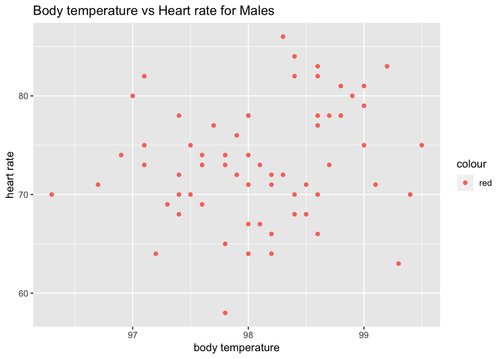

```r
ggplot(data_male) + geom_point(aes(x=data_male$body_temperature, y=data_male$heart_rate,colour="red"))+ xlab("body temperature") + ylab("heart rate") + ggtitle("Body temperature vs Heart rate for Males")
```

```r
cor(data_male$body_temperature,data_male$heart_rate)
```

```
## [1] 0.1955894
```

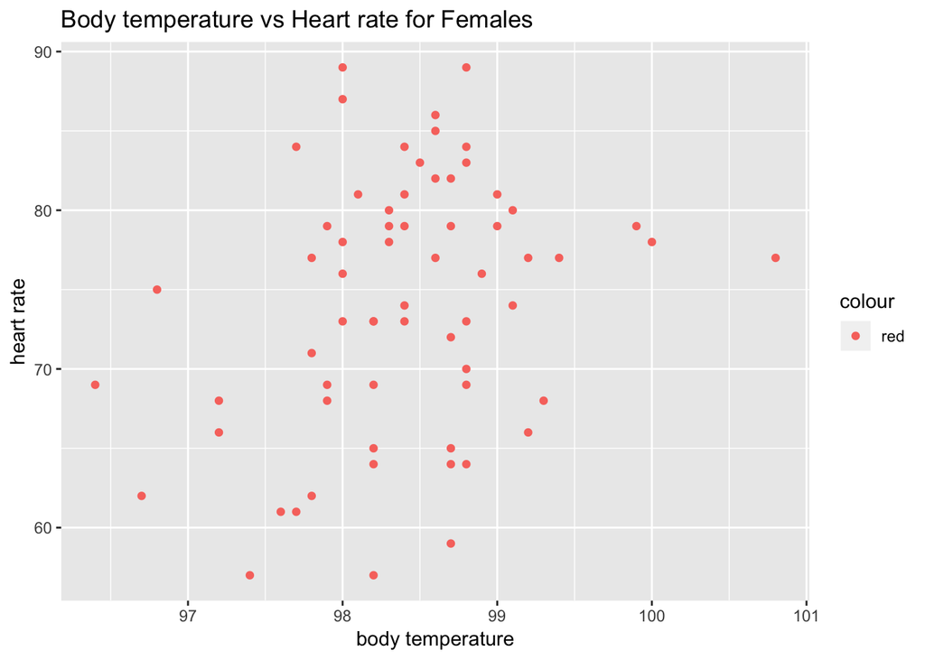

```r
ggplot(data_female) + geom_point(aes(x=data_female$body_temperature, y=data_female$heart_rate,colour="red"))+ xlab("body temperature") + ylab("heart rate") + ggtitle("Body temperature vs Heart rate for Females")
```

```r
cor(data_female$body_temperature,data_female$heart_rate)
```

```
## [1] 0.2869312
```

So,from the above graph we can infer that the linear correlation of heart rate vs body temperature for females(0.286) is a little bit better in comparison to the linear correlation of heart rate vs body temperature for males (0.195)

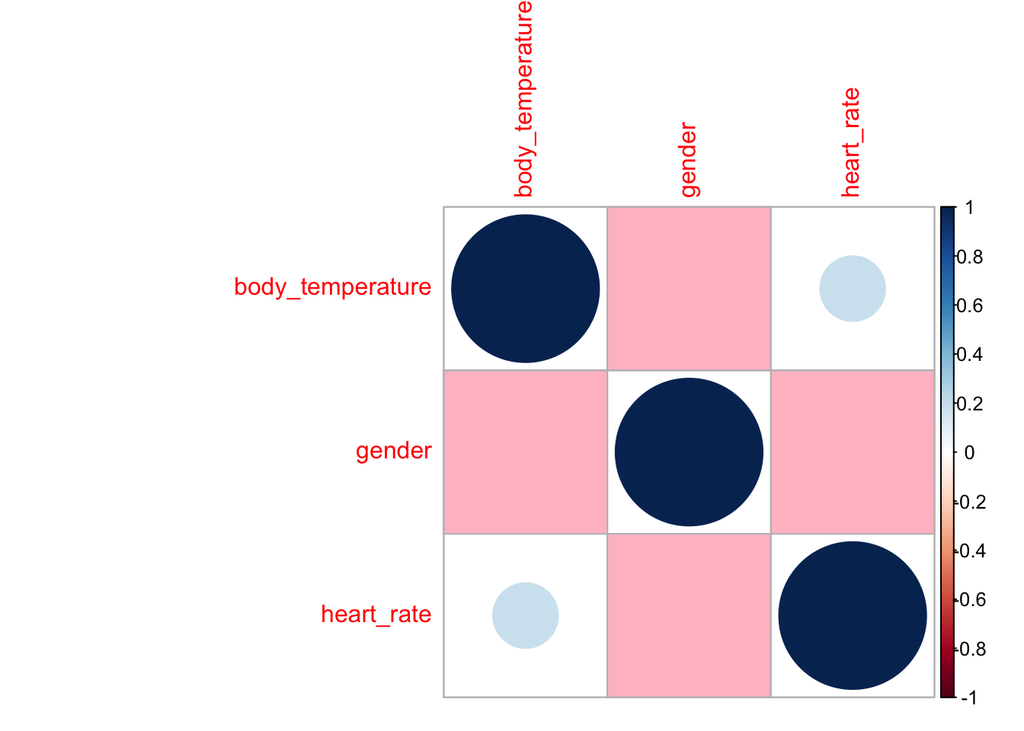

```r
corrplot::corrplot(cor(data_male),na.label.col = "pink",na.label = "square" )
```

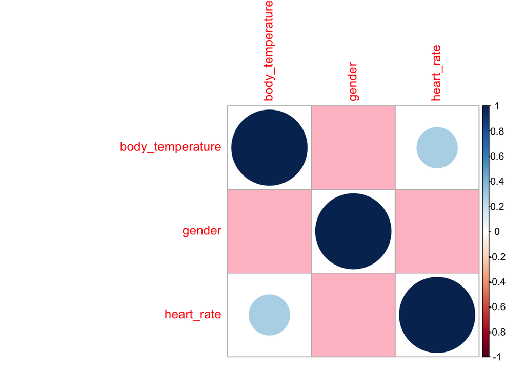

```r
corrplot::corrplot(cor(data_female),na.label.col = "pink",na.label = "square" )
```

## Question 2

The goal of this exercise to see how large n should be for the large-sample and the (parametric) bootstrap percentile method confidence intervals for the mean of an exponential population to be accurate. To be specific, let X1, . . . , Xn represent a random sample from an exponential distribution. Note that this distribution is skewed and its mean is ?? = 1/lambda. We can construct two confidence intervals for mean??? one the large-sample z-interval (interval 1) and the other a (parametric) bootstrap percentile method interval (interval 2). We would like to investigate their accuracy, i.e., how close their estimated coverage probabilities are to the assumed nominal level of confidence, for various combinations of (n, lambda). This investigation will focus on 1 ??? ?? = 0.95, lambda= 0.01, 0.1, 1,10 and n = 5, 10, 30, 100. Thus, we have a total of 4 ??? 4 = 16 combinations of (n, lambda) to investigate.

1. For a given setting, compute Monte Carlo estimates of coverage probabilities of the two intervals by simulating appropriate data, using them to construct the two confidence intervals, and repeating the process 5000 times.

```r
alpha <- 0.05
n <- 10
lambda <- 0.1
p.5k <- replicate(5000,(rexp(n,lambda)))
mu <- mean(p.5k)
stderror <- sd(p.5k)
conf.int1 <- function(mu, stderror,n , alpha){
  ci <- round(mu + c(-1, 1)* qnorm(0.975) * stderror/sqrt(n), 3)
  return(ci)
}
ci1 <- conf.int1(mu, stderror, n, alpha)
print(ci1)
```

```
## [1]  3.828 16.088
```

```r
library(boot)
x <- (rexp(n,lambda))
b <- 5000 #no of replicates
mean.par <- function(x,i){
  result <- mean(x[i])
  return(result)
}

R <- boot(data = x, R=b ,statistic = mean.par)
print(R)
```

```
##
## ORDINARY NONPARAMETRIC BOOTSTRAP
##
##
## Call:
## boot(data = x, statistic = mean.par, R = b)
##
##
## Bootstrap Statistics :
##     original      bias    std. error
## t1* 8.824138 -0.01874634    1.925065
```

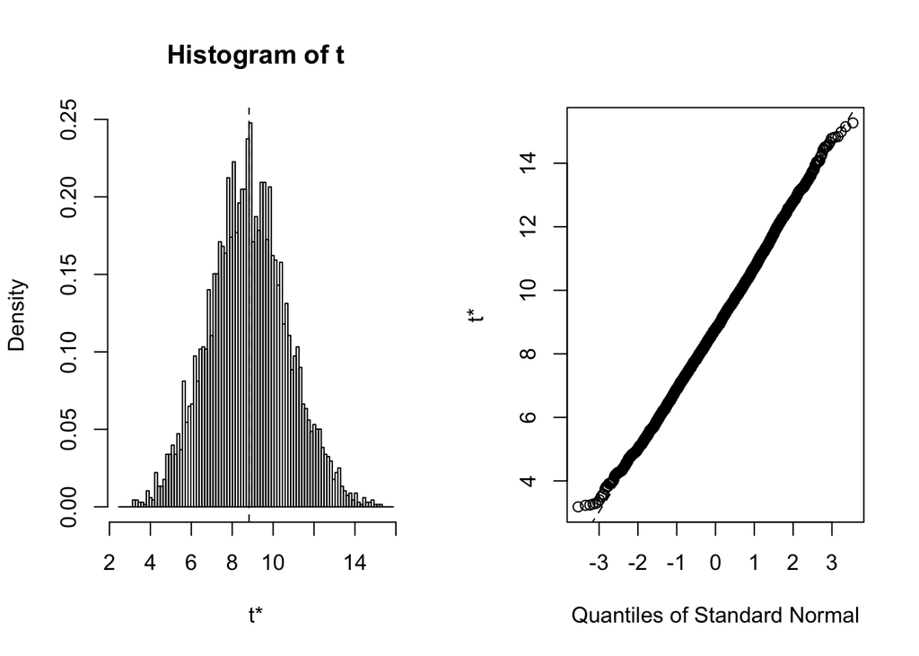

```r
plot(R)
```

```r
boot.ci(boot.out = R,conf = 0.95, type= "perc")
```

```
## BOOTSTRAP CONFIDENCE INTERVAL CALCULATIONS
## Based on 5000 bootstrap replicates
##
## CALL :
## boot.ci(boot.out = R, conf = 0.95, type = "perc")
##
## Intervals :
## Level     Percentile
## 95%   ( 5.098, 12.715 )
## Calculations and Intervals on Original Scale
```

```r
sort(R$t)[c(25,975)]
```

```
## [1] 4.175377 7.160281
```

2. Repeat (a) for the remaining combinations of (n,lambda). Present an appropriate summary of the results.

```r
n1 <- c(5, 10, 30, 100)
lambda1 <- c(0.01, 0.1, 1,10)
comb <- expand.grid(n1,lambda1)

for (i in n1){
  for (j in lambda1){
    mu1 <- mean(replicate(5000,(rexp(i,j))))
    sd1 <- (sd(replicate(5000,(rexp(i,j)))))
    values_ci1 <- conf.int1(mu1, sd1,i , alpha)
    values_ci21 <- boot(data = (rexp(i,j)), R=b ,statistic = mean.par)
    values_ci22 <- sort(values_ci21$t)[c(25,975)]
    values_mean <- 1/j
    res <- ((c(values_ci1,values_ci22,values_mean)))
    print(res)
  }
}
```

```
## [1]  12.14400 188.42400  19.36838  44.37938 100.00000
## [1]  1.257000 18.768000  2.200152  6.777711 10.000000
## [1] 0.1220000 1.8900000 0.2078877 0.7441093 1.0000000
## [1] 0.01200000 0.18700000 0.06480958 0.07791822 0.10000000
## [1]  37.75800 161.89500  32.50640  64.86911 100.00000
## [1]  3.825000 16.220000  4.198269  6.481546 10.000000
## [1] 0.3700000 1.6190000 0.4159694 0.7528299 1.0000000
## [1] 0.03900000 0.16200000 0.02756135 0.04671536 0.10000000
## [1]  64.1400 135.6970  84.4471 114.0125 100.0000
## [1]  6.353000 13.529000  8.866448 12.746895 10.000000
## [1] 0.6440000 1.3590000 0.6759135 0.9110770 1.0000000
## [1] 0.06400000 0.13600000 0.05501678 0.07797538 0.10000000
## [1]  80.28200 119.53400  80.16893  95.98374 100.00000
## [1]  8.002000 11.933000  6.996975  8.138660 10.000000
## [1] 0.8020000 1.1930000 0.7758821 0.9415685 1.0000000
## [1] 0.08000000 0.12000000 0.08363007 0.09990080 0.10000000
```

3. Interpret all the results. Be sure to answer the following questions: In case of the large-sample interval, how large n is needed for the interval to be accurate? Likewise, in case of the bootstrap interval, how large n is needed for the interval to be accurate? Do these answers depend on lambda? Can we say that one method is more accurate than the other? Which interval would you recommend? Provide justification for all your conclusions.

Ans. For different values of n and lambda from the C.I results we can see that:

In case of the large-sample interval n=5 sufficies to be large enough to give appropriate outcome irrespective to the value of lambda.

4. Do your conclusions in (c) depend on the specific values of lambda that were fixed in advance? Explain.

Yes, the conclusion in (c) depends on the specific values of lambda that were fixed in advance for the percentile bootstrap interval.

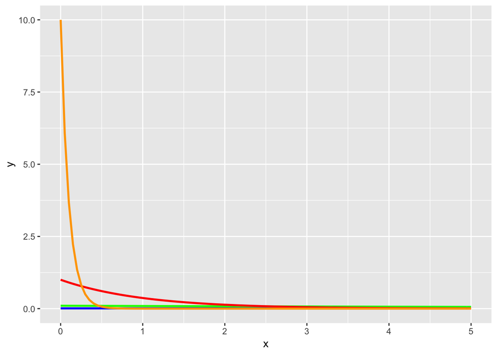

```r
h<-ggplot(data.frame(x=c(0,5)),aes(x=x))
h<-h+stat_function(fun=dexp,geom = "line",size=1,col="blue",args = (mean=0.01))
h<-h+stat_function(fun=dexp,geom = "line",size=1,col="green",args = (mean=0.1))
h<-h+stat_function(fun=dexp,geom = "line",size=1,col="red",args = (mean=1))
h<-h+stat_function(fun=dexp,geom = "line",size=1,col="orange",args = (mean=10))
print(h)
```

Coming back to the original goal of this exercise to see how large n should be for the large-sample and the (parametric) bootstrap percentile method confidence intervals for the mean of an exponential population to be accurate. To answer this question:

a)The large-sample interval : Even n=5 sufficies to be the large enough because this method takes 95% of the data distribution excluding the variational part(which is between 0 to 1).